# NYPD Shooting Incident Data Analysis

2023-01-27

Make sure to install packages tidyverse, ggplot2, randomForest and ROCR before running document.

Loading NYPD Shooting Incident Data (Historic) from https://catalog.data.gov/dataset. Empty or blank data has been filled with NA, Dropped columns for the purpose of this analysis were Incident_Key OCCUR_TIME, PRECINCT, JURISDICTION, LOCATION, X_COORD_CD, Y_COORD_CD, Latitude, Longitude, and Lon_Lat.

```r
nypd_Data <- read.csv("https://data.cityofnewyork.us/api/views/833y-fsy8/rows.csv", na.strings = "")
head(nypd_Data)
```

```
##   INCIDENT_KEY OCCUR_DATE OCCUR_TIME     BORO PRECINCT JURISDICTION_CODE
## 1    236168668 11/11/2021   15:04:00 BROOKLYN       79                 0
## 2    231008085 07/16/2021   22:05:00 BROOKLYN       72                 0
## 3    230717903 07/11/2021   01:09:00 BROOKLYN       79                 0
## 4    237712309 12/11/2021   13:42:00 BROOKLYN       81                 0
## 5    224465521 02/16/2021   20:00:00   QUEENS      113                 0
## 6    228252164 05/15/2021   04:13:00   QUEENS      113                 0
##   LOCATION_DESC STATISTICAL_MURDER_FLAG PERP_AGE_GROUP PERP_SEX
## 1          <NA>                   false           <NA>     <NA>
## 2          <NA>                   false          45-64        M
## 3          <NA>                   false            <18        M
## 4          <NA>                   false           <NA>     <NA>
## 5          <NA>                   false           <NA>     <NA>
## 6          <NA>                    true           <NA>     <NA>
##                  PERP_RACE VIC_AGE_GROUP VIC_SEX                 VIC_RACE
```

[output cut: 20 more lines]

```r
nypd_Data <- nypd_Data[, c(-1,-3,-5,-6,-7,-15,-16,-17,-18,-19)]
head(nypd_Data)
```

```
##   OCCUR_DATE     BORO STATISTICAL_MURDER_FLAG PERP_AGE_GROUP PERP_SEX
## 1 11/11/2021 BROOKLYN                   false           <NA>     <NA>
## 2 07/16/2021 BROOKLYN                   false          45-64        M
## 3 07/11/2021 BROOKLYN                   false            <18        M
## 4 12/11/2021 BROOKLYN                   false           <NA>     <NA>
## 5 02/16/2021   QUEENS                   false           <NA>     <NA>
## 6 05/15/2021   QUEENS                    true           <NA>     <NA>
##                  PERP_RACE VIC_AGE_GROUP VIC_SEX                 VIC_RACE
## 1                     <NA>         18-24       M                    BLACK
## 2 ASIAN / PACIFIC ISLANDER         25-44       M ASIAN / PACIFIC ISLANDER
## 3                    BLACK         25-44       M                    BLACK
## 4                     <NA>         25-44       M                    BLACK
## 5                     <NA>         25-44       M                    BLACK
## 6                     <NA>         25-44       M                    BLACK
```

There’s quite a bit of missing data from this set spanning 16 years, first we will change the OCCUR_DATE column to a date variable, all other variables are change to factor variables. There’s a couple strange values in PERP_AGE_GROUP 1020, 224, and 940. None of these values are remotly close to the other levels for that variable, could be a entry error. Those observations were dropped. Only complete entries were kept from this set. Strangely, the age groups for both perpetrator and victims have unequal age groups except for 25-44 and 45-64.

```
## [1] "Missing Data:"
```

```
##   OCCUR_DATE     BORO STATISTICAL_MURDER_FLAG PERP_AGE_GROUP PERP_SEX PERP_RACE
## 1 2021-11-11 BROOKLYN                   false           <NA>     <NA>      <NA>
## 4 2021-12-11 BROOKLYN                   false           <NA>     <NA>      <NA>
## 5 2021-02-16   QUEENS                   false           <NA>     <NA>      <NA>
## 6 2021-05-15   QUEENS                    true           <NA>     <NA>      <NA>
## 7 2021-04-14    BRONX                    true           <NA>     <NA>      <NA>
## 8 2021-12-10    BRONX                   false           <NA>     <NA>      <NA>
##   VIC_AGE_GROUP VIC_SEX VIC_RACE OCCUR_Year
## 1         18-24       M    BLACK       2021
## 4         25-44       M    BLACK       2021
## 5         25-44       M    BLACK       2021
## 6         25-44       M    BLACK       2021
## 7         18-24       M    BLACK       2021
## 8         25-44       M    BLACK       2021
```

```
## [1] "Data for Analysis:"
```

```
##    OCCUR_DATE      BORO STATISTICAL_MURDER_FLAG PERP_AGE_GROUP PERP_SEX
## 2  2021-07-16  BROOKLYN                   false          45-64        M
## 3  2021-07-11  BROOKLYN                   false            <18        M
## 10 2021-03-07  BROOKLYN                    true          25-44        M
## 11 2021-07-21 MANHATTAN                   false          25-44        M
## 13 2021-05-09     BRONX                    true          25-44        M
## 18 2021-06-16     BRONX                    true          25-44        M
##                   PERP_RACE VIC_AGE_GROUP VIC_SEX                 VIC_RACE
## 2  ASIAN / PACIFIC ISLANDER         25-44       M ASIAN / PACIFIC ISLANDER
## 3                     BLACK         25-44       M                    BLACK
## 10           BLACK HISPANIC         25-44       M           WHITE HISPANIC
## 11                    BLACK         25-44       M                    BLACK
## 13                    BLACK         25-44       M           BLACK HISPANIC
## 18                    BLACK         25-44       F                    BLACK
##    OCCUR_Year
## 2        2021
## 3        2021
## 10       2021
## 11       2021
## 13       2021
## 18       2021
```

```
##    OCCUR_DATE                    BORO      STATISTICAL_MURDER_FLAG
##  Min.   :2006-01-01   BRONX        :4888   false:13027
##  1st Qu.:2008-06-01   BROOKLYN     :6073   true : 3222
##  Median :2011-01-16   MANHATTAN    :2235
##  Mean   :2012-05-25   QUEENS       :2462
##  3rd Qu.:2016-03-06   STATEN ISLAND: 591
##  Max.   :2021-12-31
##
##  PERP_AGE_GROUP PERP_SEX                           PERP_RACE     VIC_AGE_GROUP
##  18-24  :5844   F:  371   AMERICAN INDIAN/ALASKAN NATIVE:    2   <18    :1869
##  25-44  :5202   M:14413   ASIAN / PACIFIC ISLANDER      :  141   18-24  :6035
##  UNKNOWN:3148   U: 1465   BLACK                         :10667   25-44  :7042
##  <18    :1463             BLACK HISPANIC                : 1203   45-64  :1125
##  45-64  : 535             UNKNOWN                       : 1802   65+    : 123
##  65+    :  57             WHITE                         :  272   UNKNOWN:  55
##  (Other):   0             WHITE HISPANIC                : 2162
##  VIC_SEX                             VIC_RACE       OCCUR_Year
##  F: 1710   AMERICAN INDIAN/ALASKAN NATIVE:    7   2006   :1890
##  M:14531   ASIAN / PACIFIC ISLANDER      :  257   2008   :1737
##  U:    8   BLACK                         :11093   2009   :1639
##            BLACK HISPANIC                : 1639   2007   :1606
##            UNKNOWN                       :   47   2010   :1213
##            WHITE                         :  514   2011   : 992
##            WHITE HISPANIC                : 2692   (Other):7172
```

From the initial 25596 observtions we are left with a new data matrix with 16249 observations or analysis. But what is going on with the observations that had missing data? Let’s take a quick look.

```
##    OCCUR_DATE                    BORO      STATISTICAL_MURDER_FLAG
##  Min.   :2006-01-01   BRONX        :2512   false:7638
##  1st Qu.:2011-10-28   BROOKLYN     :4291   true :1706
##  Median :2014-11-12   MANHATTAN    :1030
##  Mean   :2015-04-13   QUEENS       :1366
##  3rd Qu.:2019-07-12   STATEN ISLAND: 145
##  Max.   :2021-12-31
##
##  PERP_AGE_GROUP PERP_SEX                             PERP_RACE
##  <18    :   0   F   :   0   UNKNOWN                       :  34
##  1020   :   0   M   :   0   AMERICAN INDIAN/ALASKAN NATIVE:   0
##  18-24  :   0   U   :  34   ASIAN / PACIFIC ISLANDER      :   0
##  224    :   0   NA's:9310   BLACK                         :   0
##  25-44  :   0               BLACK HISPANIC                :   0
##  (Other):   0               (Other)                       :   0
##  NA's   :9344               NA's                          :9310
##  VIC_AGE_GROUP  VIC_SEX                            VIC_RACE      OCCUR_Year
##  <18    : 812   F: 693   AMERICAN INDIAN/ALASKAN NATIVE:   2   2020   :1070
##  18-24  :3568   M:8648   ASIAN / PACIFIC ISLANDER      :  97   2021   :1049
##  25-44  :4342   U:   3   BLACK                         :7187   2011   : 947
##  45-64  : 573            BLACK HISPANIC                : 846   2012   : 892
##  65+    :  44            UNKNOWN                       :  18   2014   : 731
##  UNKNOWN:   5            WHITE                         : 146   2010   : 698
##                          WHITE HISPANIC                :1048   (Other):3957
```

```
## # A tibble: 5 × 2
##   BORO          total_NA
##   <fct>            <dbl>
## 1 BRONX             7524
## 2 BROOKLYN         12853
## 3 MANHATTAN         3078
## 4 QUEENS            4080
## 5 STATEN ISLAND      429
```

Brooklyn and the Bronx have the most missing values of the New York city districts. These districts also have the most incidents from our analysis data. There could be an issue with the rate of these occurances and the documenting process. Or maybe a new entry system was introduced at some point. I could have filled the NAs with the “mean” of the variable columns, however because of what this data describes it is best not to speculate and skew the data further into various sub groups.

Let’s take a visual look at the data we will use for our analysis, specifically those incidents that resulted in murder.

```
## # A tibble: 5 × 2
## # Groups:   BORO [5]
##   BORO              n
##   <fct>         <int>
## 1 BRONX          1042
## 2 BROOKLYN       1136
## 3 MANHATTAN       427
## 4 QUEENS          489
## 5 STATEN ISLAND   128
```

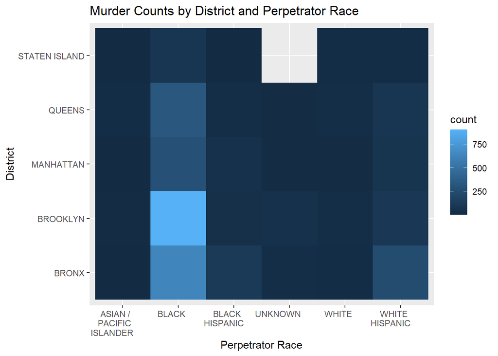

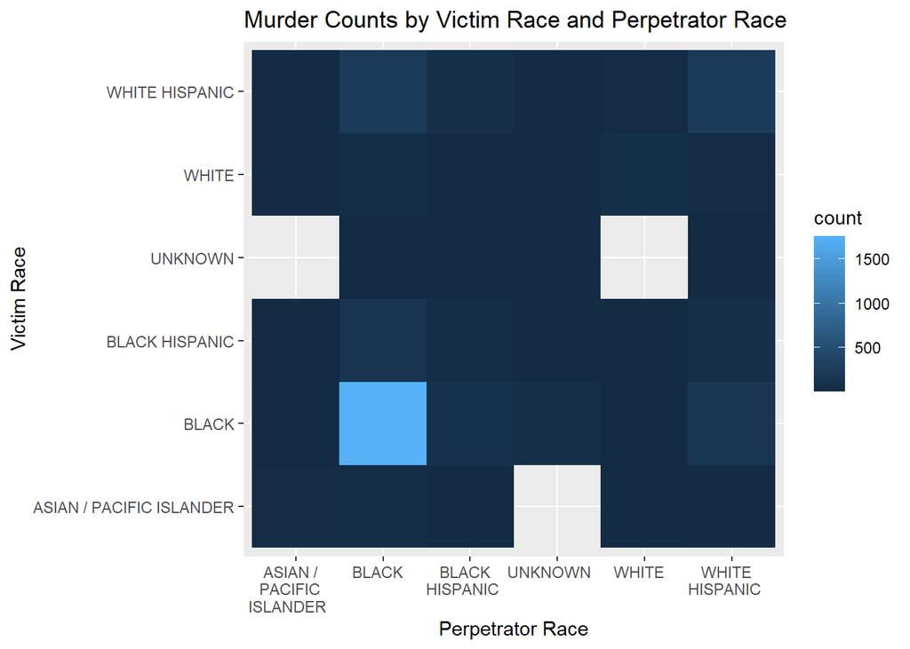

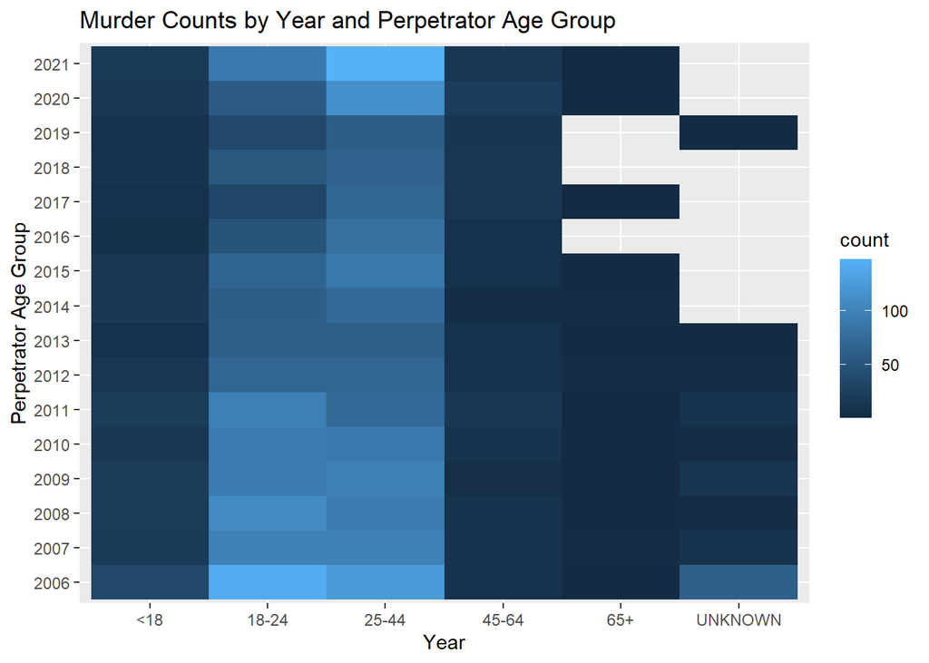

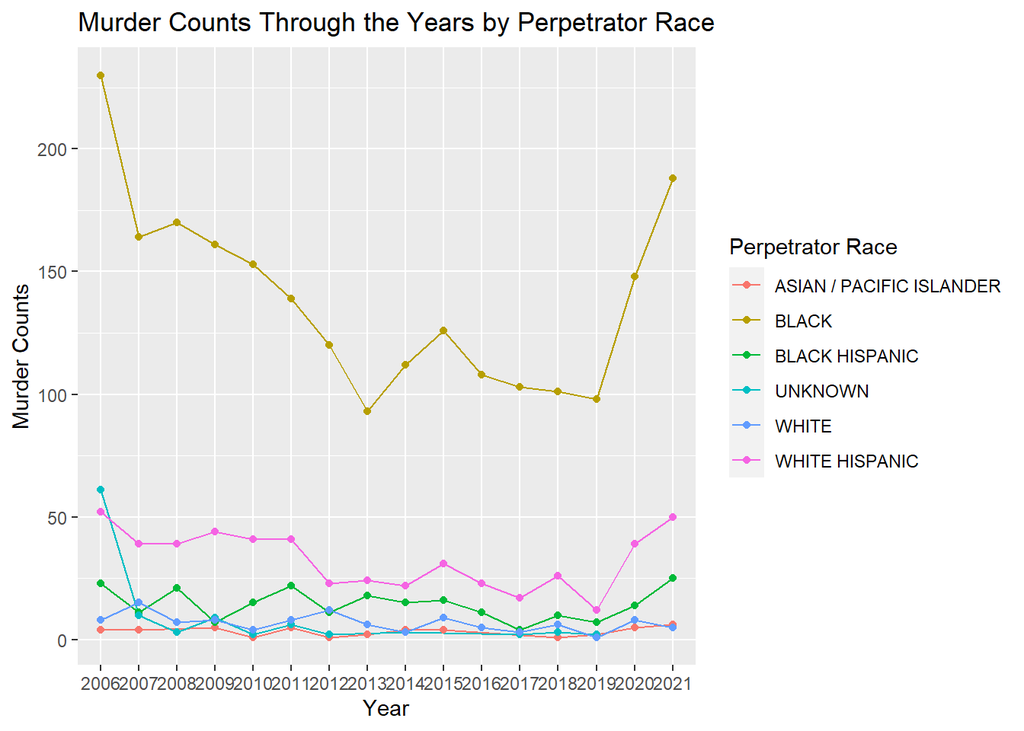

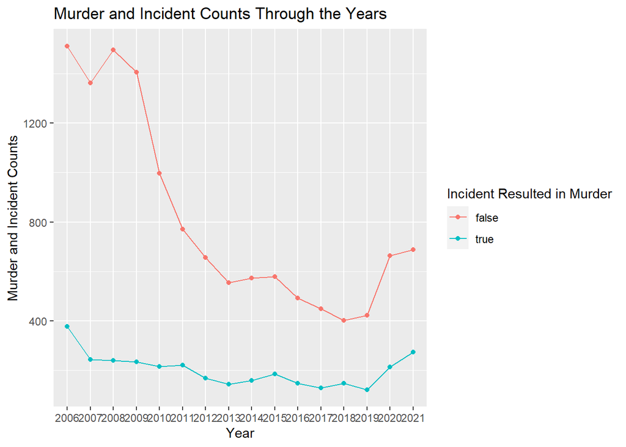

Looking at these visualizations, Brooklyn appears to have the most murder recordings out of the districts. Of the recorder murder incidents Black on Black killings are the most occuring. Young adults and Adults have the most murder counts through the years. Chronologically Blacks have consistently held higher murder rates than other race groups. Wholistically shooting incidents that did not result in murder far exceed those that did. There is an incident spike during the financil crisis and during the COVID years.

Let’s see if we can classify if an incident will result in a murder based on the variables we have. First we will try Logistic Regression and then Random Forest, after training and testing these models we will compare them at the end.

We will randomly split our data 70% for training and 30% for testing.

```
##
## Call:
## glm(formula = STATISTICAL_MURDER_FLAG ~ ., family = binomial(link = "logit"),
##     data = train[, -1])
##
## Deviance Residuals:
##     Min       1Q   Median       3Q      Max
## -1.4709  -0.7406  -0.6358  -0.1846   3.1448
##
## Coefficients:
##                                    Estimate Std. Error z value Pr(>|z|)
## (Intercept)                       -25.00699  418.68920  -0.060 0.952373
## BOROBROOKLYN                       -0.11975    0.06183  -1.937 0.052773 .
## BOROMANHATTAN                      -0.16636    0.07958  -2.091 0.036572 *
## BOROQUEENS                         -0.09848    0.07761  -1.269 0.204481
## BOROSTATEN ISLAND                  -0.10555    0.12722  -0.830 0.406714
## PERP_AGE_GROUP18-24                 0.08272    0.09078   0.911 0.362175
## PERP_AGE_GROUP25-44                 0.36274    0.09257   3.918 8.91e-05 ***
## PERP_AGE_GROUP45-64                 0.74493    0.14041   5.305 1.12e-07 ***
## PERP_AGE_GROUP65+                   0.20536    0.38755   0.530 0.596176
## PERP_AGE_GROUPUNKNOWN              -2.66726    0.22170 -12.031  < 2e-16 ***
## PERP_SEXM                          -0.06365    0.14919  -0.427 0.669631
## PERP_SEXU                           1.60044    0.35264   4.538 5.67e-06 ***
## PERP_RACEASIAN / PACIFIC ISLANDER  12.89255  378.59056   0.034 0.972834
## PERP_RACEBLACK                     12.48229  378.59049   0.033 0.973698
## PERP_RACEBLACK HISPANIC            12.30608  378.59050   0.033 0.974069
## PERP_RACEUNKNOWN                   11.96041  378.59058   0.032 0.974797
## PERP_RACEWHITE                     13.00210  378.59053   0.034 0.972603
## PERP_RACEWHITE HISPANIC            12.49256  378.59049   0.033 0.973677
## VIC_AGE_GROUP18-24                  0.39312    0.09475   4.149 3.34e-05 ***
## VIC_AGE_GROUP25-44                  0.50118    0.09458   5.299 1.16e-07 ***
## VIC_AGE_GROUP45-64                  0.50274    0.12273   4.096 4.20e-05 ***
## VIC_AGE_GROUP65+                    0.96384    0.26228   3.675 0.000238 ***
## VIC_AGE_GROUPUNKNOWN                0.44051    0.41239   1.068 0.285433
## VIC_SEXM                           -0.10949    0.07738  -1.415 0.157054
## VIC_SEXU                            0.29804    1.19475   0.249 0.803010
## VIC_RACEASIAN / PACIFIC ISLANDER   11.50942  178.80130   0.064 0.948676
## VIC_RACEBLACK                      11.43042  178.80120   0.064 0.949027
## VIC_RACEBLACK HISPANIC             11.29623  178.80121   0.063 0.949625
## VIC_RACEUNKNOWN                     9.89977  178.80297   0.055 0.955846
```

[output cut: 12 more lines]

```
## OCCUR_Year2017                     -0.57425    0.14192  -4.046 5.20e-05 ***
## OCCUR_Year2018                     -0.32084    0.14052  -2.283 0.022417 *
## OCCUR_Year2019                     -0.67646    0.14636  -4.622 3.80e-06 ***
## OCCUR_Year2020                     -0.54250    0.12093  -4.486 7.26e-06 ***
## OCCUR_Year2021                     -0.39610    0.11725  -3.378 0.000730 ***
## ---
## Signif. codes:  0 '***' 0.001 '**' 0.01 '*' 0.05 '.' 0.1 ' ' 1
##
## (Dispersion parameter for binomial family taken to be 1)
##
##     Null deviance: 11368  on 11350  degrees of freedom
## Residual deviance: 10498  on 11305  degrees of freedom
## AIC: 10590
##
## Number of Fisher Scoring iterations: 12
```

```
##     0     1
## 11306    45
```

```
## [1] 0.7996652
```

From this Logistic Rgression model we have an accuracy of 79.97%, not too bad for an initial attempt. I can say that ths data has definite issues with varability (By truth or lack of documentation and entry). Several groups are very prominent, which may or may not be an accurate representation of the incidents occuring in these Districts and the whole of New York City. A comparison to the demographics of New York City through the years may be beneficial for perspective. Intrestingly the year of occurancy, perpetrator age group and victim age groups are the most significant variables to predict a murder or not for this model. Only one District, Manhattan, is significant.

Let’s move on to creating a Random Forest model.

```
##
## Call:
##  randomForest(formula = STATISTICAL_MURDER_FLAG ~ ., data = train[,      -1], proximity = TRUE)
##                Type of random forest: classification
##                      Number of trees: 500
## No. of variables tried at each split: 2
##
##         OOB estimate of  error rate: 20.55%
## Confusion matrix:
##       false true class.error
## false  8986   92  0.01013439
## true   2241   32  0.98592169
```

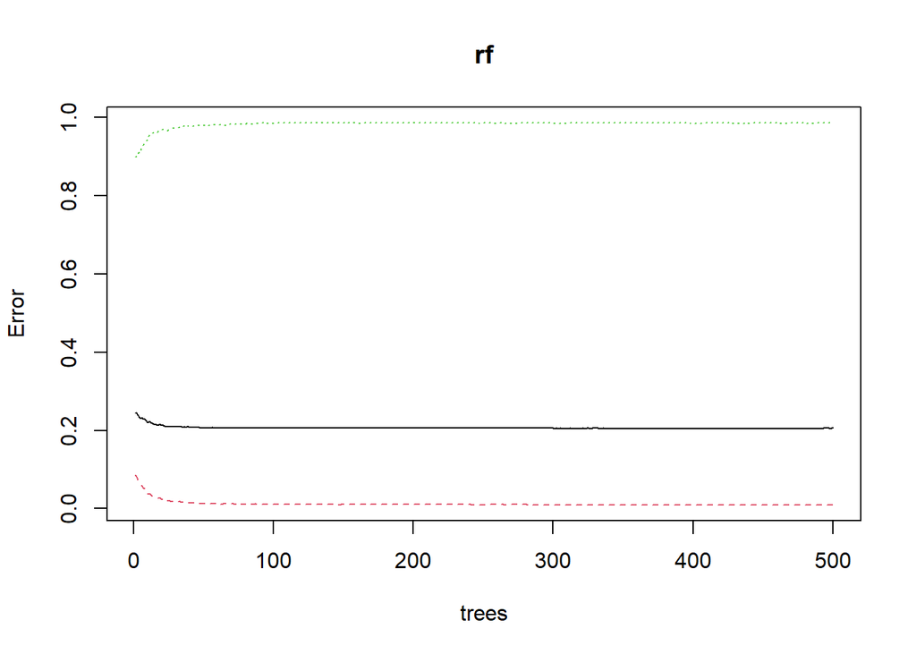

```
## mtry = 2  OOB error = 20.51%
## Searching left ...
## Searching right ...
## mtry = 3     OOB error = 21.81%
## -0.06357388 0.01
```

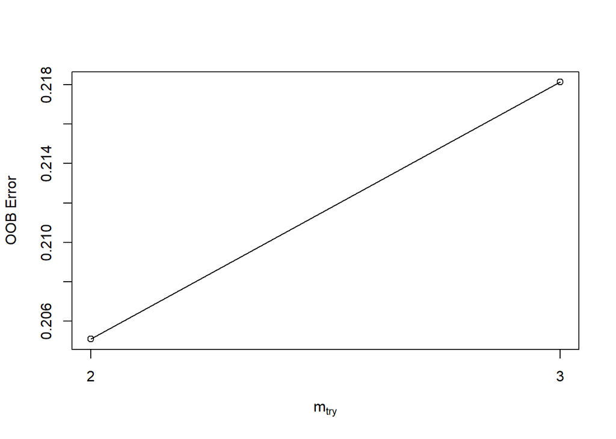

```
##       mtry  OOBError
## 2.OOB    2 0.2050921
## 3.OOB    3 0.2181306
```

```
## [1] 2
```

```
##
## Call:
##  randomForest(formula = STATISTICAL_MURDER_FLAG ~ ., data = train[,      -1], mtry = best.m, importance = TRUE, ntree = 500)
##                Type of random forest: classification
##                      Number of trees: 500
## No. of variables tried at each split: 2
##
##         OOB estimate of  error rate: 20.45%
## Confusion matrix:
##       false true class.error
## false  8997   81  0.00892267
## true   2240   33  0.98548174
```

```
##                    false        true MeanDecreaseAccuracy MeanDecreaseGini
## BORO            1.668927  -7.5850266            -2.153133        116.90694
## PERP_AGE_GROUP 17.941993  -6.1698559            21.040098        212.39170
## PERP_SEX        4.223557  -6.0921504             2.719235         35.35160
## PERP_RACE       6.340761 -11.8297228             1.604276        118.25681
## VIC_AGE_GROUP   4.468500 -14.2088351            -3.210562        107.15020
## VIC_SEX        -7.117704  -0.3712856            -6.619284         35.07871
## VIC_RACE        4.784184  -7.1246366             1.034189        100.17165
## OCCUR_Year     19.281793 -15.9414175            15.818779        277.59234
```

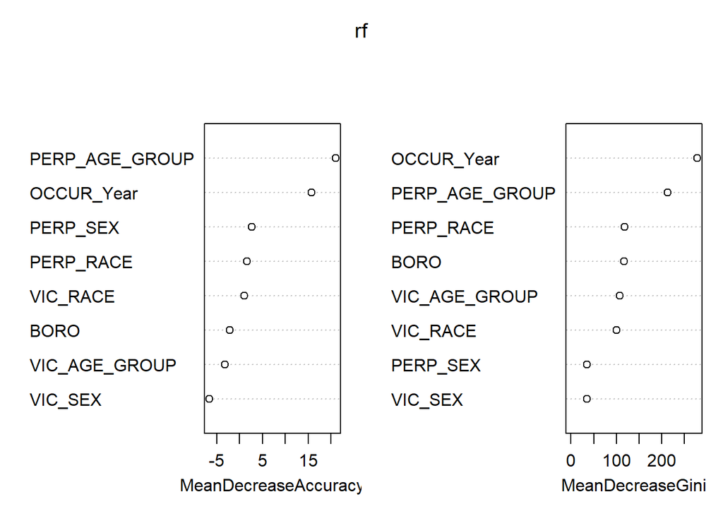

Finally let’s apply these models on our Testing data set, and compare the misclassification rates and ROC curves.

```
## A performance instance
##   'Area under the ROC curve'
```

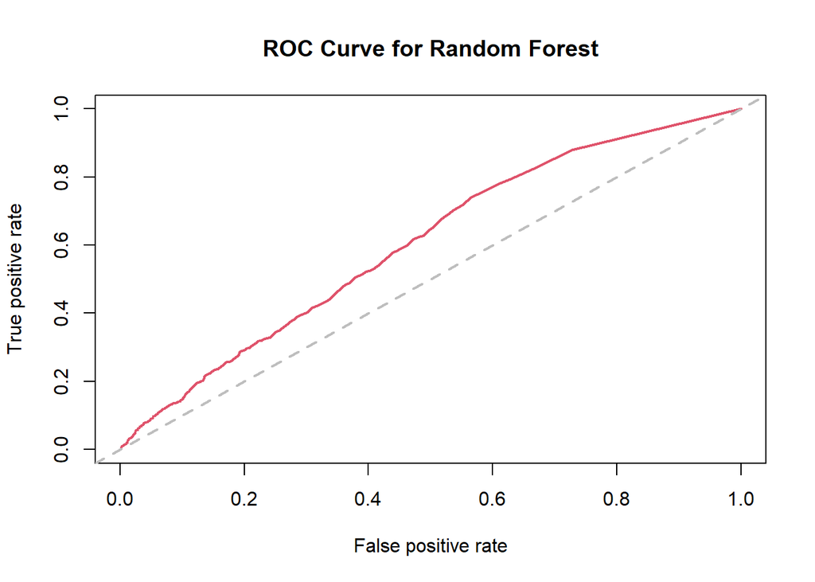

```
## A performance instance
##   'Area under the ROC curve'
```

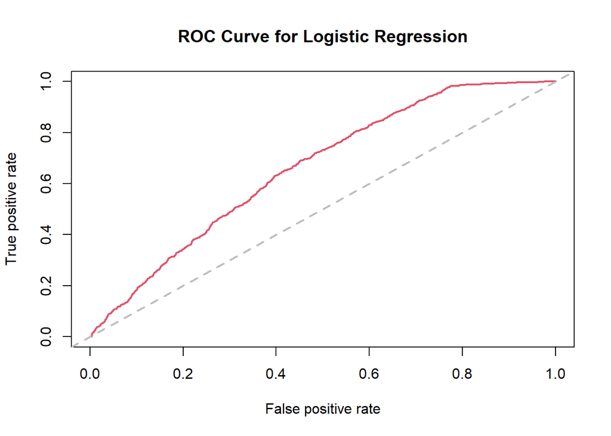

```
## [1] "Misclassification Rate: Logistic Regression"
```

```
## [1] 19.58
```

```
## [1] "Misclassification Rate: Random Forest"
```

```
## [1] 19.62
```

Bias Identification: Because this data is limited in scope I think it would be beneficial to merge demographic data from the Districts of New York City to get a better picture of what is going on and if this data is representative of that District. Also compare this shooting data to other crimes. It would also be wise to look into why there is a good amount of missing data from specific Districts, the systems that collect the data, and people recording the incident data. I think some potential bias I have is as an outsider of New York and never visited New York City, seeing how the city is portrayed in media, news, etc. definitely paints the city in two extreme views. Some of my speculation may stem from my limited knowledge of the city and would benefit looking at related data and statisitics.